# Create a fsspec ReferenceFileSystem for a large set of remote GeoTIFF files

by [Christoph Gohlke](https://www.cgohlke.com)

This Python script uses the tifffile and imagecodecs packages to create a [fsspec ReferenceFileSystem](https://github.com/fsspec/kerchunk) file in JSON format for the [earthbigdata](http://sentinel-1-global-coherence-earthbigdata.s3-website-us-west-2.amazonaws.com) set, which consists of 1,033,422 GeoTIFF files stored on AWS. The ReferenceFileSystem is used to create a multi-dimensional xarray dataset.

See discussion at kerchunk/issues/78.

```python
import os
import base64

import tifffile
import imagecodecs.numcodecs
import matplotlib.pyplot
import numcodecs
import fsspec
import xarray
import zarr
```

## Get a list of all remote TIFF files

Call the aws command line app to recursively list all files in the earthbigdata set. Cache the output in a local file. Filter the list for TIFF files and remove the common path.

```python
if not os.path.exists('earthbigdata.txt'):
    os.system(
        'aws s3 ls sentinel-1-global-coherence-earthbigdata/data/tiles'
        ' --recursive > earthbigdata.txt'
    )

with open('earthbigdata.txt') as fh:
    tiff_files = [
        line.split()[-1][11:] for line in fh.readlines() if '.tif' in line
    ]
print('Number of TIFF files:', len(tiff_files))
```

```
Number of TIFF files: 1033422
```

## Define metadata to describe the dataset

Define labels, coordinate arrays, file name regex patterns, and categories for all dimensions in the earthbigdata set.

```python
baseurl = (
    'https://'
    'sentinel-1-global-coherence-earthbigdata.s3.us-west-2.amazonaws.com'
    '/data/tiles/'
)

chunkshape = (1200, 1200)
fillvalue = 0

latitude_label = 'latitude'
latitude_pattern = rf'(?P<{latitude_label}>[NS]\d+)'
latitude_coordinates = [
    (j * -0.00083333333 - 0.000416666665 + i)
    for i in range(82, -79, -1)
    for j in range(1200)
]
latitude_category = {}
i = 0
for j in range(82, -1, -1):
    latitude_category[f'N{j:-02}'] = i
    i += 1
for j in range(1, 79):
    latitude_category[f'S{j:-02}'] = i
    i += 1

longitude_label = 'longitude'
longitude_pattern = rf'(?P<{longitude_label}>[EW]\d+)'
longitude_coordinates = [
    (j * 0.00083333333 + 0.000416666665 + i)
    for i in range(-180, 180)
    for j in range(1200)
]
longitude_category = {}
i = 0
for j in range(180, 0, -1):
    longitude_category[f'W{j:-03}'] = i
    i += 1
for j in range(180):
    longitude_category[f'E{j:-03}'] = i
    i += 1

season_label = 'season'
season_category = {'winter': 0, 'spring': 1, 'summer': 2, 'fall': 3}
season_coordinates = list(season_category.keys())
season_pattern = rf'_(?P<{season_label}>{"|".join(season_category)})'

polarization_label = 'polarization'
polarization_category = {'vv': 0, 'vh': 1, 'hv': 2, 'hh': 3}
polarization_coordinates = list(polarization_category.keys())
polarization_pattern = (
    rf'_(?P<{polarization_label}>{"|".join(polarization_category)})'
)

coherence_label = 'coherence'
coherence_category = {
    '06': 0,
    '12': 1,
    '18': 2,
    '24': 3,
    '36': 4,
    '48': 5,
}
coherence_coordinates = list(int(i) for i in coherence_category.keys())
coherence_pattern = (
    rf'_COH(?P<{coherence_label}>{"|".join(coherence_category)})'
)

orbit_label = 'orbit'
orbit_coordinates = list(range(1, 176))
orbit_pattern = rf'_(?P<{orbit_label}>\d+)'

flightdirection_label = 'flightdirection'
flightdirection_category = {'A': 0, 'D': 1}
flightdirection_coordinates = list(flightdirection_category.keys())
flightdirection_pattern = (
    rf'(?P<{flightdirection_label}>[{"|".join(flightdirection_category)}])_'
)
```

## Open a file for writing the fsspec ReferenceFileSystem in JSON format

```python
jsonfile = open('earthbigdata.json', 'w', newline='\n')
```

## Write the coordinate arrays

Add the coordinate arrays to a zarr group, convert it to a fsspec ReferenceFileSystem JSON string, and write it to the open file.

```python
coordinates = {}
zarrgroup = zarr.open_group(coordinates)
zarrgroup.array(
    longitude_label, data=longitude_coordinates, dtype='float32'
).attrs['_ARRAY_DIMENSIONS'] = [longitude_label]

zarrgroup.array(
    latitude_label, data=latitude_coordinates, dtype='float32'
).attrs['_ARRAY_DIMENSIONS'] = [latitude_label]

zarrgroup.array(
    season_label,
    data=season_coordinates,
    dtype=object,
    object_codec=numcodecs.VLenUTF8(),
    compression=None,
).attrs['_ARRAY_DIMENSIONS'] = [season_label]

zarrgroup.array(
    polarization_label,
    data=polarization_coordinates,
    dtype=object,
    object_codec=numcodecs.VLenUTF8(),
    compression=None,
).attrs['_ARRAY_DIMENSIONS'] = [polarization_label]

zarrgroup.array(
    coherence_label,
    data=coherence_coordinates,
    dtype='uint8',
    compression=None,
).attrs['_ARRAY_DIMENSIONS'] = [coherence_label]

zarrgroup.array(orbit_label, data=orbit_coordinates, dtype='int32').attrs[
    '_ARRAY_DIMENSIONS'
] = [orbit_label]

zarrgroup.array(
    flightdirection_label,
    data=flightdirection_coordinates,
    dtype=object,
    object_codec=numcodecs.VLenUTF8(),
    compression=None,
).attrs['_ARRAY_DIMENSIONS'] = [flightdirection_label]

# base64 encode any values containing non-ascii characters
for k, v in coordinates.items():
    try:
        coordinates[k] = v.decode()
    except UnicodeDecodeError:
        coordinates[k] = 'base64:' + base64.b64encode(v).decode()

coordinates_json = tifffile.ZarrStore._json(coordinates).decode()

jsonfile.write(coordinates_json[:-2])  # skip the last newline and brace
```

```
69839
```

## Create a TiffSequence from a list of file names

Filter the list of GeoTIFF files for files containing coherence 'COH' data. The regex pattern and categories are used to parse the file names for chunk indices.

Note: the created TiffSequence cannot be used to access any files. The file names do not refer to exising files. The baseurl is later used to get the real location of the files.

```python
mode = 'COH'
fileseq = tifffile.TiffSequence(
    [file for file in tiff_files if '_' + mode in file],
    pattern=(
        latitude_pattern
        + longitude_pattern
        + season_pattern
        + polarization_pattern
        + coherence_pattern
    ),
    categories={
        latitude_label: latitude_category,
        longitude_label: longitude_category,
        season_label: season_category,
        polarization_label: polarization_category,
        coherence_label: coherence_category,
    },
)
assert len(fileseq.files) == 444821
assert fileseq.files_missing == 5119339
assert fileseq.shape == (161, 360, 4, 4, 6)
assert fileseq.labels == (
    'latitude',
    'longitude',
    'season',
    'polarization',
    'coherence',
)
print(fileseq)
```

```
TiffSequence
 N00E005_fall_vv_COH12.tif
 files: 444821 (5119339 missing)
 shape: 161, 360, 4, 4, 6
 labels: latitude, longitude, season, polarization, coherence
```

## Create a ZarrTiffStore from the TiffSequence

Define 'axestiled' to tile the latitude and longitude dimensions of the TiffSequence with the first and second image/chunk dimensions. Define extra 'zattrs' to create a xarray compatible store.

```python
store = fileseq.aszarr(
    dtype='uint8',
    chunkshape=chunkshape,
    fillvalue=fillvalue,
    axestiled={0: 0, 1: 1},
    zattrs={
        '_ARRAY_DIMENSIONS': [
            season_label,
            polarization_label,
            coherence_label,
            latitude_label,
            longitude_label,
        ]
    },
)
print(store)
```

```
ZarrFileSequenceStore
 shape: 4, 4, 6, 193200, 432000
 chunks: 1, 1, 1, 1200, 1200
 dtype: uint8
 fillvalue: 0
```

## Append the ZarrTiffStore to the open ReferenceFileSystem file

Use the mode name to create a zarr subgroup. Use the 'imagecodecs_tiff' numcodecs compatible codec for decoding TIFF files.

```python
store.write_fsspec(
    jsonfile,
    baseurl,
    groupname=mode,
    codec_id='imagecodecs_tiff',
    _append=True,
)
```

## Repeat for the other modes

Repeat the TiffSequence->aszarr->write_fsspec workflow for the other modes.

```python
for mode in (
    'AMP',
    'tau',
    'rmse',
    'rho',
):
    fileseq = tifffile.TiffSequence(
        [file for file in tiff_files if '_' + mode in file],
        pattern=(
            latitude_pattern
            + longitude_pattern
            + season_pattern
            + polarization_pattern
        ),
        categories={
            latitude_label: latitude_category,
            longitude_label: longitude_category,
            season_label: season_category,
            polarization_label: polarization_category,
        },
    )
    print(fileseq)
    with fileseq.aszarr(
        dtype='uint16',
        chunkshape=chunkshape,
        fillvalue=fillvalue,
        axestiled={0: 0, 1: 1},
        zattrs={
            '_ARRAY_DIMENSIONS': [
                season_label,
                polarization_label,
                latitude_label,
                longitude_label,
            ]
        },
    ) as store:
        print(store)
        store.write_fsspec(
            jsonfile,
            baseurl,
            groupname=mode,
            codec_id='imagecodecs_tiff',
            _append=True,
        )


for mode in ('inc', 'lsmap'):
    fileseq = tifffile.TiffSequence(
        [file for file in tiff_files if '_' + mode in file],
        pattern=(
            latitude_pattern
            + longitude_pattern
            + orbit_pattern
            + flightdirection_pattern
        ),
        categories={
            latitude_label: latitude_category,
            longitude_label: longitude_category,
            # orbit has no category
            flightdirection_label: flightdirection_category,
        },
    )
    print(fileseq)
    with fileseq.aszarr(
        dtype='uint8',
        chunkshape=chunkshape,
        fillvalue=fillvalue,
        axestiled={0: 0, 1: 1},
        zattrs={
            '_ARRAY_DIMENSIONS': [
                orbit_label,
                flightdirection_label,
                latitude_label,
                longitude_label,
            ]
        },
    ) as store:
        print(store)
        store.write_fsspec(
            jsonfile,
            baseurl,
            groupname=mode,
            codec_id='imagecodecs_tiff',
            _append=True,
        )
```

```
TiffSequence
 N00E005_fall_vh_AMP.tif
 files: 187693 (739667 missing)
 shape: 161, 360, 4, 4
 labels: latitude, longitude, season, polarization
ZarrFileSequenceStore
 shape: 4, 4, 193200, 432000
 chunks: 1, 1, 1200, 1200
 dtype: uint16
 fillvalue: 0
TiffSequence
 N00E005_fall_vv_tau.tif
 files: 98331 (829029 missing)
 shape: 161, 360, 4, 4
 labels: latitude, longitude, season, polarization
ZarrFileSequenceStore
 shape: 4, 4, 193200, 432000
 chunks: 1, 1, 1200, 1200
 dtype: uint16
 fillvalue: 0
TiffSequence
 N00E005_fall_vv_rmse.tif
 files: 98331 (829029 missing)
 shape: 161, 360, 4, 4
 labels: latitude, longitude, season, polarization
ZarrFileSequenceStore
 shape: 4, 4, 193200, 432000
 chunks: 1, 1, 1200, 1200
 dtype: uint16
 fillvalue: 0
TiffSequence
 N00E005_fall_vv_rho.tif
 files: 98331 (829029 missing)
 shape: 161, 360, 4, 4
 labels: latitude, longitude, season, polarization
ZarrFileSequenceStore
 shape: 4, 4, 193200, 432000
 chunks: 1, 1, 1200, 1200
 dtype: uint16
 fillvalue: 0
TiffSequence
 N00E005_124D_inc.tif
 files: 52956 (20233044 missing)
 shape: 161, 360, 175, 2
 labels: latitude, longitude, orbit, flightdirection
ZarrFileSequenceStore
 shape: 175, 2, 193200, 432000
 chunks: 1, 1, 1200, 1200
 dtype: uint8
 fillvalue: 0
TiffSequence
 N00E005_124D_lsmap.tif
 files: 52959 (20233041 missing)
 shape: 161, 360, 175, 2
 labels: latitude, longitude, orbit, flightdirection
ZarrFileSequenceStore
 shape: 175, 2, 193200, 432000
 chunks: 1, 1, 1200, 1200
 dtype: uint8
 fillvalue: 0
```

## Close the JSON file

```python
jsonfile.write('\n}')
jsonfile.close()
```

## Use the fsspec ReferenceFileSystem file to create a xarray dataset

Register imagecodecs.numcodecs before using the ReferenceFileSystem.

```python
imagecodecs.numcodecs.register_codecs()
```

### Create a fsspec mapper instance from the ReferenceFileSystem file

Specify the 'target_protocol' to load a local file.

```python
mapper = fsspec.get_mapper(
    'reference://',
    fo='earthbigdata.json',
    target_protocol='file',
    remote_protocol='http',
)
```

### Create a xarray dataset from the mapper

Use 'mask_and_scale' to disable conversion to floating point.

```python
dataset = xarray.open_dataset(
    mapper,
    engine='zarr',
    mask_and_scale=False,
    backend_kwargs={'consolidated': False},
)
print(dataset)
```

```
<xarray.Dataset>
Dimensions:          (season: 4, polarization: 4, latitude: 193200,
                      longitude: 432000, coherence: 6, flightdirection: 2,
                      orbit: 175)
Coordinates:
  * coherence        (coherence) uint8 6 12 18 24 36 48
  * flightdirection  (flightdirection) object 'A' 'D'
  * latitude         (latitude) float32 82.0 82.0 82.0 ... -79.0 -79.0 -79.0
  * longitude        (longitude) float32 -180.0 -180.0 -180.0 ... 180.0 180.0
  * orbit            (orbit) int32 1 2 3 4 5 6 7 ... 169 170 171 172 173 174 175
  * polarization     (polarization) object 'vv' 'vh' 'hv' 'hh'
  * season           (season) object 'winter' 'spring' 'summer' 'fall'
Data variables:
    AMP              (season, polarization, latitude, longitude) uint16 ...
    COH              (season, polarization, coherence, latitude, longitude) uint8 ...
    inc              (orbit, flightdirection, latitude, longitude) uint8 ...
    lsmap            (orbit, flightdirection, latitude, longitude) uint8 ...
    rho              (season, polarization, latitude, longitude) uint16 ...
    rmse             (season, polarization, latitude, longitude) uint16 ...
    tau              (season, polarization, latitude, longitude) uint16 ...
```

### Select the Southern California region in the dataset

```python
socal = dataset.sel(latitude=slice(36, 32.5), longitude=slice(-121, -115))
print(socal)
```

```
<xarray.Dataset>
Dimensions:          (season: 4, polarization: 4, latitude: 4200,
                      longitude: 7200, coherence: 6, flightdirection: 2,
                      orbit: 175)
Coordinates:
  * coherence        (coherence) uint8 6 12 18 24 36 48
  * flightdirection  (flightdirection) object 'A' 'D'
  * latitude         (latitude) float32 36.0 36.0 36.0 36.0 ... 32.5 32.5 32.5
  * longitude        (longitude) float32 -121.0 -121.0 -121.0 ... -115.0 -115.0
  * orbit            (orbit) int32 1 2 3 4 5 6 7 ... 169 170 171 172 173 174 175
  * polarization     (polarization) object 'vv' 'vh' 'hv' 'hh'
  * season           (season) object 'winter' 'spring' 'summer' 'fall'
Data variables:
    AMP              (season, polarization, latitude, longitude) uint16 ...
    COH              (season, polarization, coherence, latitude, longitude) uint8 ...
    inc              (orbit, flightdirection, latitude, longitude) uint8 ...
    lsmap            (orbit, flightdirection, latitude, longitude) uint8 ...
    rho              (season, polarization, latitude, longitude) uint16 ...
    rmse             (season, polarization, latitude, longitude) uint16 ...
    tau              (season, polarization, latitude, longitude) uint16 ...
```

### Plot a selection of the dataset

The few GeoTIFF files comprising the selection are transparently downloaded, decoded, and stitched to an in-memory numpy array and plotted using matplotlib.

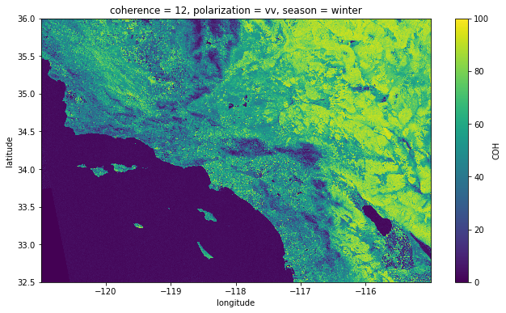

```python
image = socal['COH'].loc['winter', 'vv', 12]
assert image[100, 100] == 53
xarray.plot.imshow(image, size=6, aspect=1.8)
matplotlib.pyplot.show()
```

## System information

Print information about the software used to run this script.

```python
def system_info():
    import sys
    import datetime
    import numpy
    import matplotlib
    import tifffile
    import imagecodecs
    import numcodecs
    import fsspec
    import xarray
    import zarr

    return '\n'.join(
        (
            sys.executable,
            f'Python {sys.version}',
            '',
            f'numpy {numpy.__version__}',
            f'matplotlib {matplotlib.__version__}',
            f'tifffile {tifffile.__version__}',
            f'imagecodecs {imagecodecs.__version__}',
            f'numcodecs {numcodecs.__version__}',
            f'fsspec {fsspec.__version__}',
            f'xarray {xarray.__version__}',
            f'zarr {zarr.__version__}',
            '',
            str(datetime.datetime.now()),
        )
    )


print(system_info())
```

```
X:\Python310\python.exe
Python 3.10.2 (tags/v3.10.2:a58ebcc, Jan 17 2022, 14:12:15) [MSC v.1929 64 bit (AMD64)]

numpy 1.21.5
matplotlib 3.5.1
tifffile 2022.2.2
imagecodecs 2021.11.20
numcodecs 0.9.1
fsspec 2022.01.0
xarray 0.21.1
zarr 2.10.3

2022-02-03 12:43:37.601610
```